# Assingment_1_Answers

Ritesh Ingale

December 24, 2015

This document contains the summary statistic and analysis on Taxi Service Dataset. Loading required libraries

```r
suppressMessages(library(dplyr))
library(chron)
```

Step 1 : Acquire the Dataset

```r
tsd <- read.csv("TS_Dataset.csv", header = TRUE, sep = ",", stringsAsFactors = FALSE)
```

Step 2 : Refine the Dataset Correction of spelling mistakes

```r
tsd <- tsd %>% rename(ID = ï..ID)
```

Selecting the important variable for statistic

```r
tsd <- tsd %>% select(1:3, dtArrive, dtBegin, Sum, ServiceID, 17:20, DistanceTotal, RouteLength)
```

Filter out the unwanted obeservations

```r
tsd <- tsd %>% filter(CarID != "NULL", dtArrive != "NULL", dtBegin != "NULL", AddrFromGpsY != "NULL", AddrToGpsX != "NULL", RouteLength != "NULL")
```

Convert dtArrive and dtBegin into HH:mm:ss format

```r
tsd$dtArrive <- gsub(".\\d$", "", tsd$dtArrive)
tsd$dtBegin  <- gsub(".\\d$", "", tsd$dtBegin)
```

The oders in dataset are captured from 12:00 to 12:59 (1 hour)

```r
tsd$dtArrive <- paste0("12:", tsd$dtArrive)
tsd$dtBegin <- paste0("12:", tsd$dtBegin)
```

calculate difference in seconds between dtBegin and dtArrive and store the result in separate variable as “time_to_reach”

```r
tsd$dtArrive <- chron(times. = tsd$dtArrive)
tsd$dtBegin <- chron(times. = tsd$dtBegin)
tsd$time_to_reach <- tsd$dtBegin - tsd$dtArrive
ch <- times(tsd$time_to_reach)
tsd$time_to_reach <- 60 * 60 * hours(ch) + minutes(ch) *60 + seconds(ch)
tsd$time_to_reach <- round(tsd$time_to_reach, digits = 0)
```

**Q1** Unique number of clients/users?

```r
unique_user_cnt <- n_distinct(tsd$Client)
unique_user_cnt
```

```
## [1] 1469
```

**Q2:** Top 10 clients/users? 2.1 Highest revenue Generator

```r
top_10_user_by_revenue <- tsd %>% group_by(Client) %>% summarise(Revenue = sum(Sum)) %>% arrange(desc(Revenue)) %>% head(10)
top_10_user_by_revenue
```

```
## Source: local data frame [10 x 2]
##
##      Client Revenue
##       (dbl)   (int)
## 1  1.03e+48   20082
## 2  1.43e+48   19867
## 3  1.21e+48   19569
## 4  1.06e+48   18983
## 5  1.32e+48   18675
## 6  1.04e+48   18442
## 7  1.25e+48   18381
## 8  1.35e+48   17937
## 9  1.08e+48   17889
## 10 1.10e+48   17884
```

2.2 Regular service consumers

```r
top_10_user_by_regularity <- tsd %>% group_by(Client) %>% summarise(freq = n()) %>% arrange(desc(freq)) %>% head(10)
top_10_user_by_regularity
```

```
## Source: local data frame [10 x 2]
##
##      Client  freq
##       (dbl) (int)
## 1  1.03e+48   112
## 2  1.21e+48   110
## 3  1.43e+48   110
## 4  1.10e+48   106
## 5  1.22e+48   105
## 6  1.06e+48   104
## 7  1.04e+48   102
## 8  1.05e+48   101
## 9  1.07e+48   101
## 10 1.08e+48   101
```

**Q3:** How are starting points distributed? Is there a specific region in which taxi company is seeing very high demand?

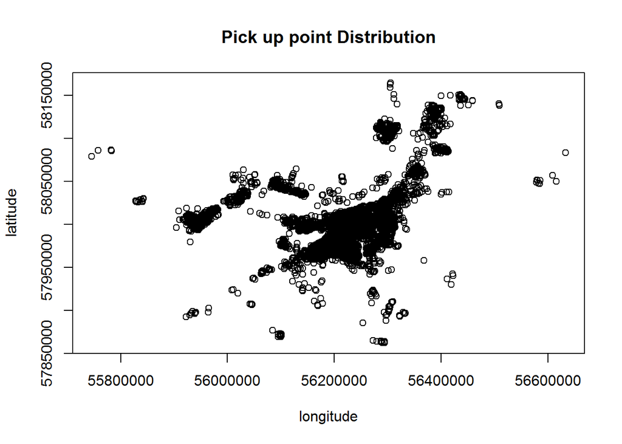

```r
plot(x = tsd$AddrFromGpsX, y = tsd$AddrFromGpsY, type = "p", main = "Pick up point Distribution", xlab = "longitude", ylab = "latitude")
```

```r
top_region <- tsd %>% group_by(AddrFromGpsX, AddrFromGpsY)  %>% summarise(popularity = n()) %>% arrange(desc(popularity)) %>% head(1)
top_region
```

```
## Source: local data frame [1 x 3]
## Groups: AddrFromGpsX [1]
##
##   AddrFromGpsX AddrFromGpsY popularity
##          (chr)        (chr)      (int)
## 1     55745744     58079410          1
```

**Q4:** What is the typical cart size/ cost per ride?

```r
cost_per_ride <- mean(tsd$Sum)
cost_per_ride
```

```
## [1] 179.1818
```

**Q5:** Find out the regular customer?

```r
regular_customer <- tsd %>% group_by(Client) %>% summarise(rides_cnt = n()) %>% arrange(desc(rides_cnt)) %>% head(10)
regular_customer
```

```
## Source: local data frame [10 x 2]
##
##      Client rides_cnt
##       (dbl)     (int)
## 1  1.03e+48       112
## 2  1.21e+48       110
## 3  1.43e+48       110
## 4  1.10e+48       106
## 5  1.22e+48       105
## 6  1.06e+48       104
## 7  1.04e+48       102
## 8  1.05e+48       101
## 9  1.07e+48       101
## 10 1.08e+48       101
```

**Q6:** Which distance regular customers travels? (large distance or short distance)

```r
tsd_without_zero_dist <- tsd %>% filter(DistanceTotal != 0)
regular_customer_type <- tsd_without_zero_dist %>% group_by(Client) %>% summarise_each(funs(mean, median), DistanceTotal)
regular_customer_type <- dplyr::left_join(regular_customer, regular_customer_type, by = "Client")
regular_customer_type
```

```
## Source: local data frame [10 x 4]
##
##      Client rides_cnt      mean median
##       (dbl)     (int)     (dbl)  (dbl)
## 1  1.03e+48       112 12.045455      5
## 2  1.21e+48       110  7.705882      5
## 3  1.43e+48       110  7.647887      6
## 4  1.10e+48       106  5.087719      5
## 5  1.22e+48       105  4.854839      3
## 6  1.06e+48       104  8.557143      4
## 7  1.04e+48       102  6.880597      5
## 8  1.05e+48       101  7.158730      4
## 9  1.07e+48       101  6.781818      5
## 10 1.08e+48       101  9.582090      4
```

**Q7:** Find most crowded pick up points?

```r
Top_pickups_points <- tsd %>% group_by(AddrFromGpsX, AddrFromGpsY) %>% summarise(customer_cnt = n()) %>% arrange(desc(customer_cnt)) %>% head(5)
Top_pickups_points
```

```
## Source: local data frame [5 x 3]
## Groups: AddrFromGpsX [5]
##
##   AddrFromGpsX AddrFromGpsY customer_cnt
##          (chr)        (chr)        (int)
## 1     55745744     58079410            1
## 2     55758071     58085994            1
## 3     55782240     58086743            1
## 4     55783360     58085509            1
## 5     55827972     58027319            1
```

**Q8:** What is the average cost paid by any customer?

```r
avg_ride_cost_customer <- tsd %>% group_by(Client) %>% summarise(typical_cost = mean(Sum)) %>% arrange(desc(typical_cost)) %>% head(10)
avg_ride_cost_customer
```

```
## Source: local data frame [10 x 2]
##
##      Client typical_cost
##       (dbl)        (dbl)
## 1  1.32e+45     940.0000
## 2  3.91e+46     500.0000
## 3  2.79e+46     470.0000
## 4  8.94e+46     470.0000
## 5  3.34e+45     410.0000
## 6  3.33e+46     410.0000
## 7  3.70e+46     408.0000
## 8  4.67e+47     405.0000
## 9  9.93e+45     400.0000
## 10 1.78e+47     393.3333
```

**Q9:** Are regular customers tends to choose specific car if yes then what average distance they travels using that car?

```r
regular_customer_details <- dplyr::left_join(regular_customer, tsd, by = "Client") %>% select(Client, CarID, DistanceTotal)
regular_customer_car <- regular_customer_details %>%
  group_by(Client, CarID) %>%
  summarise(freq_car_used = n()) %>%
  arrange(desc(freq_car_used)) %>%
  top_n(1) %>%
  filter(freq_car_used > 2) %>%
  dplyr::left_join(., regular_customer_details, by = c("Client", "CarID")) %>%
  select(Client, CarID, DistanceTotal) %>%
  group_by(Client, CarID) %>%
  summarise(avg_dist = mean(DistanceTotal)) %>%
  arrange(desc(avg_dist))
regular_customer_car
```

```
## Source: local data frame [11 x 3]
## Groups: Client [7]
##
##      Client CarID avg_dist
##       (dbl) (chr)    (dbl)
## 1  1.04e+48 26081 9.333333
## 2  1.05e+48 38375 8.000000
## 3  1.06e+48  1746 2.666667
## 4  1.06e+48  2126 1.000000
## 5  1.06e+48 61100 0.000000
## 6  1.07e+48 38197 8.500000
## 7  1.08e+48 61549 6.333333
## 8  1.21e+48  1222 5.000000
## 9  1.21e+48 38392 3.666667
## 10 1.43e+48 13530 2.333333
## 11 1.43e+48 42511 1.000000
```

**Q10:** Which type of car is more popular among the customers?

```r
car_popularity <- tsd %>% group_by(CarID) %>% summarise(Total_Revenue = sum(Sum)) %>% arrange(desc(Total_Revenue)) %>% head(10)
car_popularity
```

```
## Source: local data frame [10 x 2]
##
##    CarID Total_Revenue
##    (chr)         (int)
## 1  38168         16701
## 2  27919         16414
## 3  24643         16271
## 4  38350         15845
## 5   1125         15386
## 6  27069         14682
## 7  38296         14439
## 8  38197         14061
## 9  43000         13952
## 10 24581         13898
```

```r
avg_time_by_driver <- tsd %>% group_by(CarID) %>% summarise(avg_time = mean(time_to_reach)) %>% arrange(avg_time) %>% head(10)
```

**Q12:** From which pick up points company gets customer who travels large distance?

```r
large_dist_points <- tsd %>% group_by(AddrFromGpsX, AddrFromGpsY) %>% summarise(large_dist = max(DistanceTotal))
large_dist_points <- large_dist_points[order(large_dist_points$large_dist, decreasing = TRUE),]
head(large_dist_points, 10)
```

```
## Source: local data frame [10 x 3]
## Groups: AddrFromGpsX [10]
##
##    AddrFromGpsX AddrFromGpsY large_dist
##           (chr)        (chr)      (int)
## 1      56389329     58125817        384
## 2      56168371     57962325        329
## 3      56190663     57984646        288
## 4      56295001     58021289        266
## 5      56197572     57965839        265
## 6      56176802     57975821        250
## 7      56288600     58111786        249
## 8      56299979     57981554        246
## 9      56305364     58025150        244
## 10     56210925     57976645        215
```